# Gap Analysis Hymenoptera Combined datasets

Kylie Etter

7/8/2021

This R Code is for data analysis of the Hymenoptera for the TNC Gap Analysis. It downloads the cleaned datasets to combine that have (source, month_arabic, day_arabic, year, island, order, bee, family, genera, specificEp, scientificName) columns. Once combined can compare numbers between sources, compare locality and temporal information.

The iNaturalist data was removed from the Cal-IBIS data so there was no duplication.

Download datasets. (iNaturalist, LACM, Cal-IBIS, Bohart)

Combine datasets with the specific columns (source, month_arabic, day_arabic, year, island, order, family, genus, specificEp, scientificName).

First, removing excess columns from datasets.

```r
inat_column <- inat %>%
  select(source, month_arabic, day_arabic, year, island, order, family, genus, specificEp, scientificName)
lacm_column <- lacm %>%
  select(source, month_arabic, day_arabic, year, island, order, family, genus, specificEp, scientificName)
chis_column <- chis %>%
  select(source, month_arabic, day_arabic, year, island, order, family, genus, specificEp, scientificName) %>%
filter(!is.na(source))
bohart_column <- bohart %>%
  select(source, month_arabic, day_arabic, year, island, order, family, genus, specificEp, scientificName)
```

Now to combine. iNat = 1372, LACM = 1186, CHIS = 7621, Bohart = 6326 (bohart is all bees). 16505 total.

```r
masterdata = rbind(inat_column, lacm_column, chis_column, bohart_column)
```

Now all 4 data sets are combine! Summary stats here we go!

```r
x= table(masterdata$order)
x
```

```
##
## Hymenoptera   Hymenoptera
##         1372        15132
```

```r
table(masterdata$family)
```

```
##
##                    Andrenidae    Aphelinidae         Apidae     Bethylidae
##             68           1195              3           3079              2
##     Braconidae    Chrysididae     Colletidae    Crabronidae      Cynipidae
##             34             25           1331            232             91
##     Encyrtidae     Eulophidae     Eupelmidae    Eurytomidae     Formicidae
##              7             18              3             16           1675
##     Halictidae  Ichneumonidae   Megachilidae     Mutillidae   Perilampidae
##           6268            407            782             80              2
##     Pompilidae   Pteromalidae      Sphecidae Tenthredinidae      Tiphiidae
##             66             14            210              4             31
##       Vespidae                   Chyphotidae       Cephidae  Ceraphronidae
##            301            246              2              1              1
##    Chalcididae     Diapriidae Gasteruptiidae      Mymaridae Platygastridae
##              6              1              3             11              1
##    Scelionidae      Torymidae
##              2              5
```

```r
sum(is.na(masterdata$family))
```

```
## [1] 282
```

```r
sum(is.na(masterdata$genus))
```

```
## [1] 552
```

```r
sum(is.na(masterdata$specificEp))
```

```
## [1] 1427
```

```r
colSums(is.na(masterdata))
```

```
##         source   month_arabic     day_arabic           year         island
##              0             38            217             54            139
##          order         family          genus     specificEp scientificName
##              1            282            552           1427              0
```

Summary of taxonomic resolution by source

```r
table(inat_column$order)
```

```
##
## Hymenoptera
##         1372
```

```r
table(inat_column$family)
```

```
##
##                    Andrenidae    Aphelinidae         Apidae     Bethylidae
##             68             15              3            386              1
##     Braconidae    Chrysididae     Colletidae    Crabronidae      Cynipidae
##              5              5             28             39             72
##     Encyrtidae     Eulophidae     Eupelmidae    Eurytomidae     Formicidae
##              2              9              1              1            195
##     Halictidae  Ichneumonidae   Megachilidae     Mutillidae   Perilampidae
##            224             49             42             36              2
##     Pompilidae   Pteromalidae      Sphecidae Tenthredinidae      Tiphiidae
##             36              1             80              4              1
##       Vespidae
##             67
```

```r
x = table(inat_column$family)
print(x)
```

```
##
##                    Andrenidae    Aphelinidae         Apidae     Bethylidae
##             68             15              3            386              1
##     Braconidae    Chrysididae     Colletidae    Crabronidae      Cynipidae
##              5              5             28             39             72
##     Encyrtidae     Eulophidae     Eupelmidae    Eurytomidae     Formicidae
##              2              9              1              1            195
##     Halictidae  Ichneumonidae   Megachilidae     Mutillidae   Perilampidae
##            224             49             42             36              2
##     Pompilidae   Pteromalidae      Sphecidae Tenthredinidae      Tiphiidae
##             36              1             80              4              1
##       Vespidae
##             67
```

```r
table(chis_column$family)
```

```
##
##     Andrenidae         Apidae     Bethylidae     Braconidae       Cephidae
##            589            770              1             27              1
##  Ceraphronidae    Chalcididae    Chrysididae     Colletidae    Crabronidae
##              1              6             20            174            172
##      Cynipidae     Diapriidae     Encyrtidae     Eulophidae     Eupelmidae
##             19              1              5              9              2
##    Eurytomidae     Formicidae Gasteruptiidae     Halictidae  Ichneumonidae
##             15           1300              3           3738             12
##   Megachilidae     Mutillidae      Mymaridae Platygastridae     Pompilidae
##            146              2             11              1              8
##   Pteromalidae    Scelionidae      Sphecidae      Tiphiidae      Torymidae
##             13              2            118             13              5
##       Vespidae
##            155
```

```r
table(bohart_column$family)
```

```
##
##   Andrenidae       Apidae   Colletidae   Halictidae Megachilidae
##          590         1784         1114         2245          593
```

```r
table(lacm_column$family)
```

```
##
##                  Andrenidae        Apidae    Braconidae   Chyphotidae
##           246             1           139             2             2
##    Colletidae   Crabronidae    Formicidae    Halictidae Ichneumonidae
##            15            21           180            61           346
##  Megachilidae    Mutillidae    Pompilidae     Sphecidae     Tiphiidae
##             1            42            22            12            17
##      Vespidae
##            79
```

```r
table(masterdata$family)
```

```
##
##                    Andrenidae    Aphelinidae         Apidae     Bethylidae
##             68           1195              3           3079              2
##     Braconidae    Chrysididae     Colletidae    Crabronidae      Cynipidae
##             34             25           1331            232             91
##     Encyrtidae     Eulophidae     Eupelmidae    Eurytomidae     Formicidae
##              7             18              3             16           1675
##     Halictidae  Ichneumonidae   Megachilidae     Mutillidae   Perilampidae
##           6268            407            782             80              2
##     Pompilidae   Pteromalidae      Sphecidae Tenthredinidae      Tiphiidae
##             66             14            210              4             31
##       Vespidae                   Chyphotidae       Cephidae  Ceraphronidae
##            301            246              2              1              1
##    Chalcididae     Diapriidae Gasteruptiidae      Mymaridae Platygastridae
##              6              1              3             11              1
##    Scelionidae      Torymidae
##              2              5
```

```r
write.csv(masterdata, "gapan_alldata.csv")
```

Graphs of the different data.

Mapping the sampling on different islands by data source.

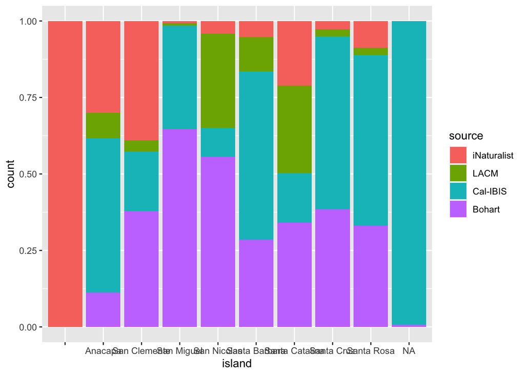

```r
library(ggplot2)
library()

y= ggplot(masterdata, aes(x=island, fill=source)) + geom_bar(position="fill")
y
```

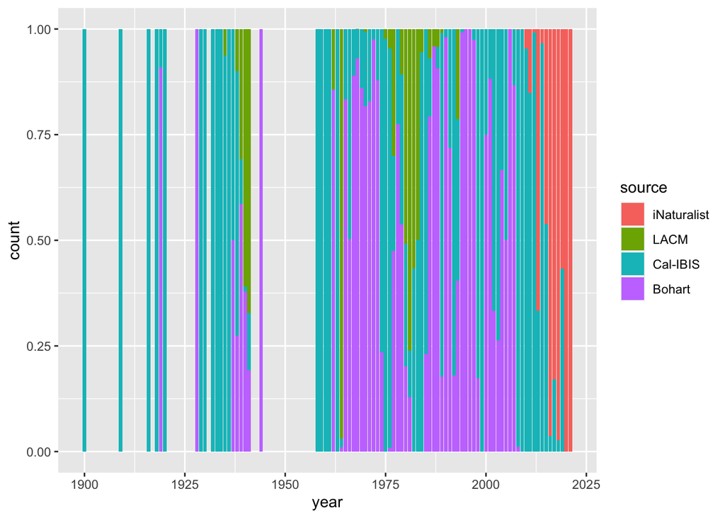

```r
r = ggplot(masterdata, aes(x=year, fill=source)) + geom_bar(position="fill")
r
```

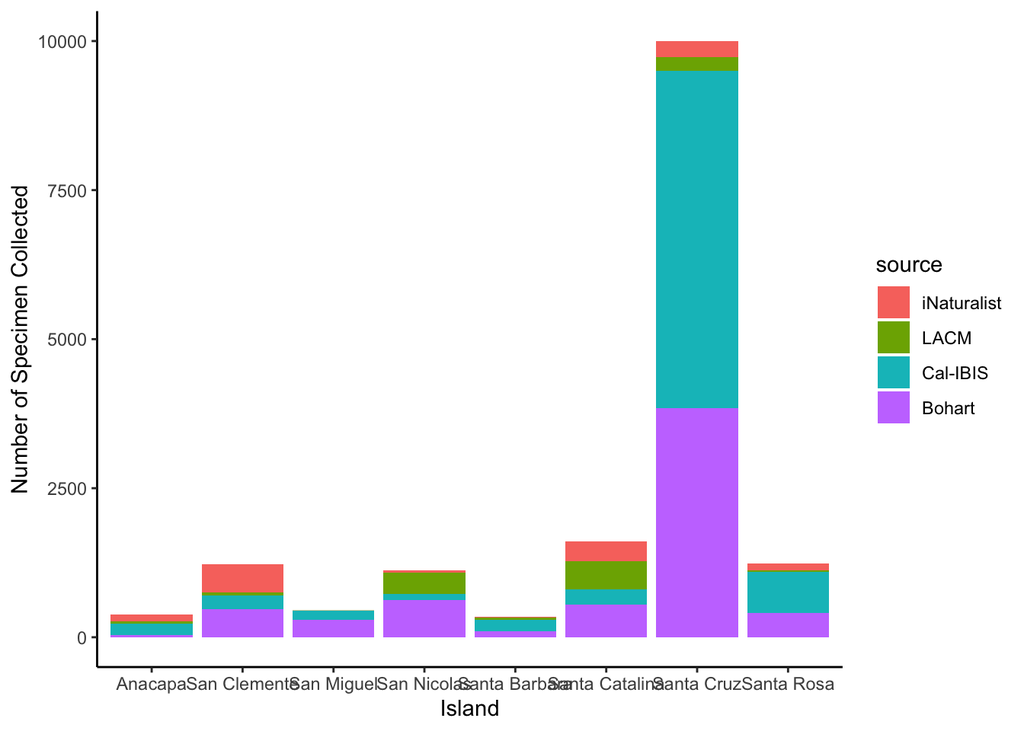

```r
masterdataisland <- masterdata %>% filter(!is.na(island))
masterdataisland <- masterdataisland[c(1:1371, 1373:16366),]

islandplot = ggplot(data = masterdataisland, aes(x = island, fill=source)) + geom_bar()
islandplot = islandplot + theme_classic() + labs(x="Island", y= "Number of Specimen Collected")
islandplot
```

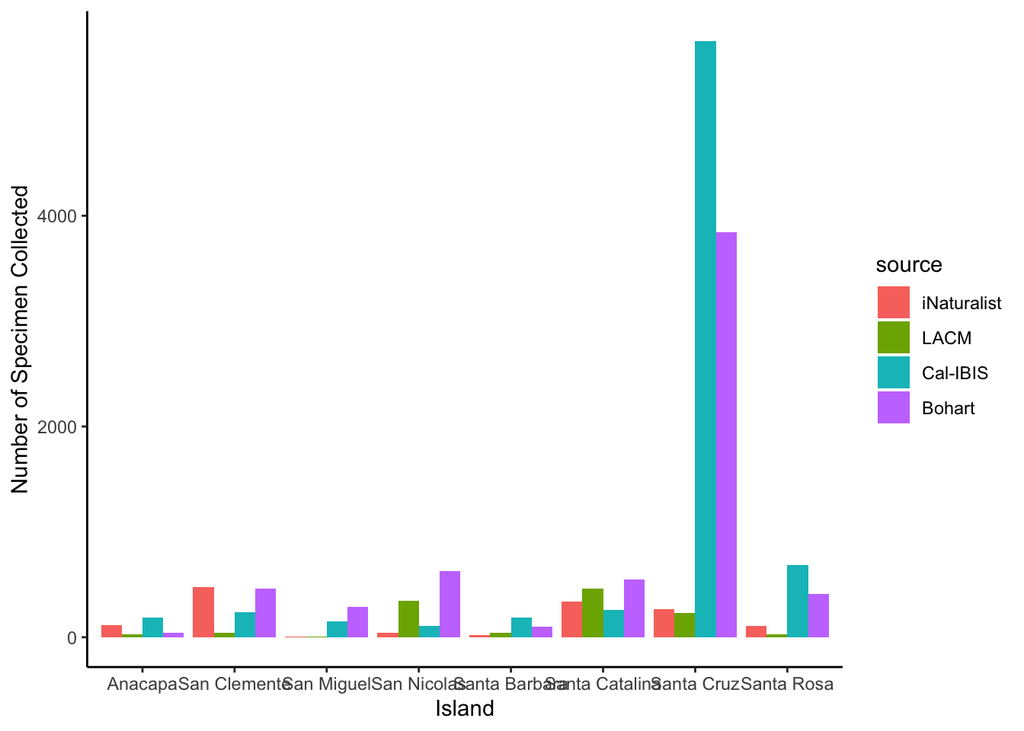

```r
islandplot2 = ggplot(data = masterdataisland, aes(x = island, fill = source)) +
    geom_bar(position = "dodge")
islandplot2 = islandplot2 + theme_classic() + labs(x="Island", y= "Number of Specimen Collected")
islandplot2
```

Graphing the temporal gaps in collections

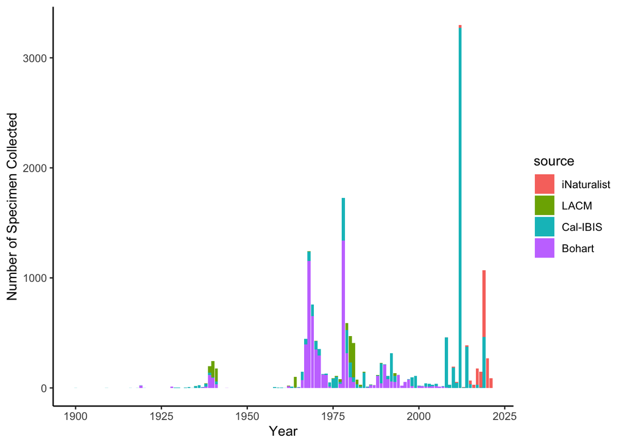

```r
yearplot = ggplot(masterdata, aes(x=year, fill=source)) + geom_bar()
yearplot = yearplot + theme_classic() + labs(x="Year", y ="Number of Specimen Collected")
yearplot
```

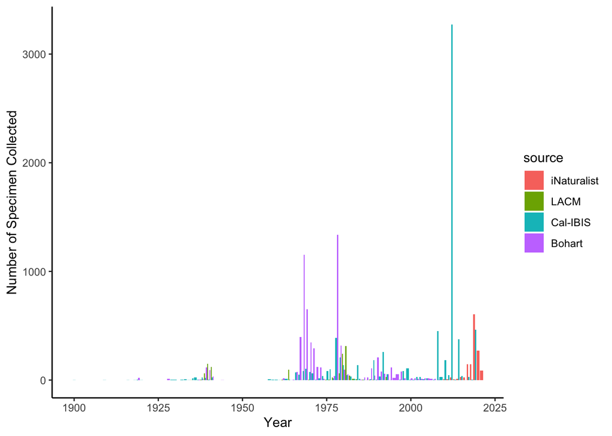

```r
yearplot2 = ggplot(masterdata, aes(x=year, fill=source)) + geom_bar(position="dodge")
yearplot2 = yearplot2 + theme_classic() + labs(x="Year", y ="Number of Specimen Collected")
yearplot2
```

Graphing the seasonal gaps in collections.

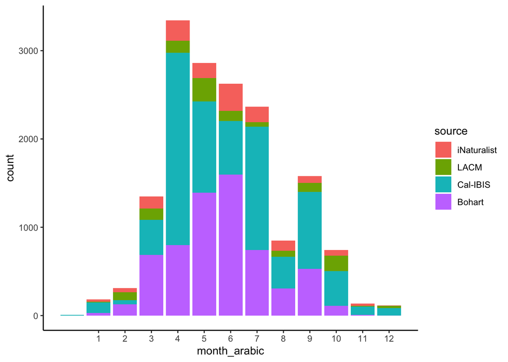

```r
monthplot = ggplot(masterdata, aes(x=month_arabic, fill=source)) + geom_bar() + scale_x_continuous(breaks = seq(1, 12, by=1))
monthplot + theme_classic()
```

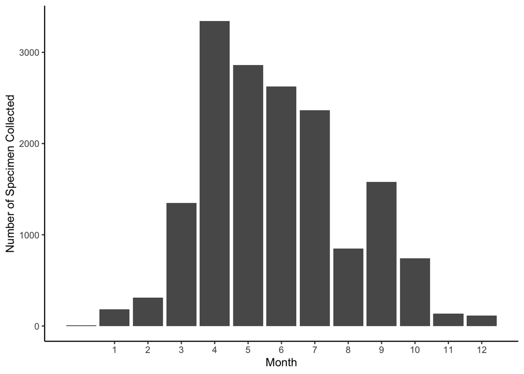

```r
monthplotall = ggplot(masterdata, aes(x=month_arabic)) + geom_bar()
monthplotall + theme_classic() + (labs(x="Month", y="Number of Specimen Collected")) + scale_x_continuous(breaks = seq(1, 12, by=1))
```